# Tutorial 07 - Bayesian Model Averaging

Olivia Fan

09 November, 2022

## Background & Introduction

Traditionally, analysis often proceeds by first selecting the best model according to some criterion and then learning about the parameters given that the selected model is the underlying truth. However, from the Bayesian perspective, an alternative is to learn the parameters for *all* candidate models and then combine the estimates according to the posterior probabilities of associated model. In this module, we will investigate this method known as *Bayesian Model Averaging*, and the advantages it has over all-or-none model selection.

## 1. Definitions

### Bayes factor

The change from prior to posterior model odds brought about by the data; equivalently, how much more likely the observed data are under one model versus another.

### Bayesian model average

A parameter estimate (or a prediction of new observations) obtained by averaging the estimates (or predictions) of the different models under consideration, each weighted by its model probability.

## 2. Libraries

The R package `BMA` provides ways of carrying out BMA for linear regression, generalized linear models, and survival or event history analysis us- ing Cox proportional hazards models.

```r
library(BMA)
library(tidyverse)
```

## 3. Example : Linear Regression

To illustrate how BMA takes account of model uncertainty about the variables to be included in lin- ear regression, we will be using the `nhanes` dataset where the variables are described in the file `nhanes-codebook.txt`. Load this data with the `load` function and specify the data file.

```r
load(file='nhanes1518.rda')
```

We first subset the dataset to include only the predictors in linear regressions module, in order to filter out some NA values:

```r
nhanes_na_removed<-cbind(nhanes1518[1:5],nhanes1518$BMXBMI)%>%
  rename(BMXBMI="nhanes1518$BMXBMI")%>%
  na.omit()
```

We fit a BMA model on the dataset:

```r
x.nhanes <-log(nhanes_na_removed[-6])
y.nhanes <-log(nhanes_na_removed[6])
y.nhanes<-as.numeric(unlist(y.nhanes))
nhanes.bicreg <- bicreg(x.nhanes, y.nhanes)
```

```
## Reordering variables and trying again:
```

```r
summary(nhanes.bicreg)
```

```
##
## Call:
## bicreg(x = x.nhanes, y = y.nhanes)
##
##
##   2  models were selected
##  Best  2  models (cumulative posterior probability =  1 ):
##
##            p!=0    EV       SD       model 1     model 2
## Intercept  100.0   0.96279  0.63627     0.81353     2.48393
## SEQN        91.1   0.13314  0.05563     0.14620       .
## WTINT2YR   100.0   0.35444  0.03372     0.35572     0.34140
## WTMEC2YR   100.0  -0.28121  0.03371    -0.28250    -0.26802
## RIDSTATR     0.0   0.00000  0.00000       .           .
## RIAGENDR   100.0   0.03389  0.00658     0.03389     0.03391
##
## nVar                                      4           3
## r2                                      0.044       0.043
## BIC                                  -714.59233  -709.94931
## post prob                               0.911       0.089
```

The BMA posterior distributions of all the parameters are produced by the command:

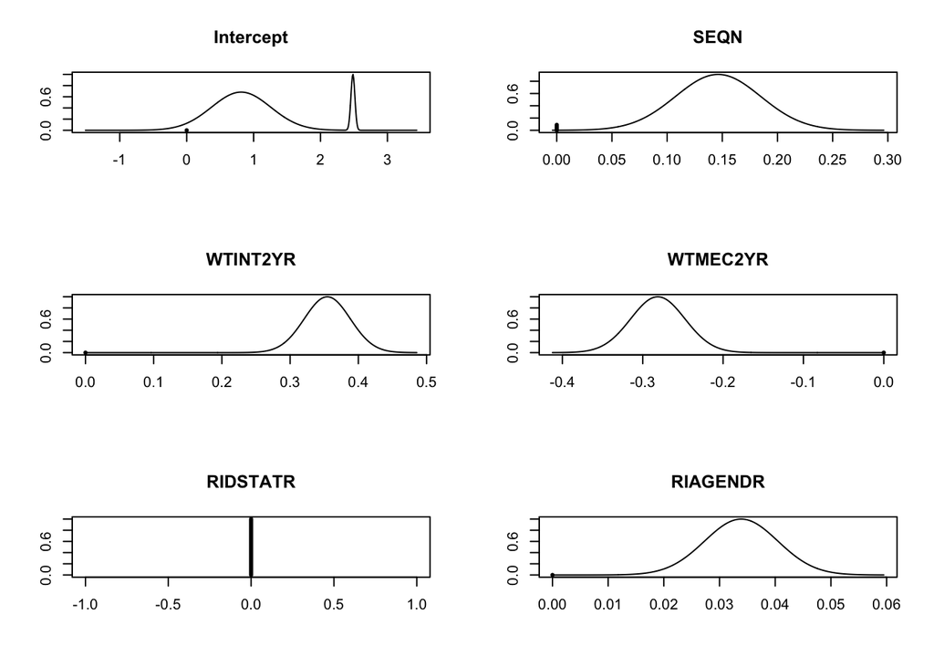

```r
plot (nhanes.bicreg,mfrow=c(3,2))
```

## 4 Example: Logistic Regression

```r
nhanes_na_removed<-cbind(nhanes1518[1:5],nhanes1518$BMXBMI,nhanes1518$RIDAGEYR,nhanes1518$INDHHIN2)%>%
  rename(BMXBMI="nhanes1518$BMXBMI")%>%
  rename(income = "nhanes1518$INDHHIN2")%>%
  rename(RIDAGEYR = "nhanes1518$RIDAGEYR")%>%
  na.omit()
# turn quantitative variable into categorical variable
nhanes_na_removed$income<-as.character(nhanes_na_removed$income)
```

Refer to the website for encoding of income categories:

https://wwwn.cdc.gov/nchs/nhanes/2011-2012/demo_g.htm#INDHHIN2

We want to first drop categories with values 77 (Refused) and 99 (Don’t Know) first:

```r
nhanes_na_removed <- subset(nhanes_na_removed, income!="77" & income!="99")
```

Then we transform the variable `RIAGENDR` to be binary:

```r
nhanes_na_removed<-nhanes_na_removed%>%
  mutate(Gender_binary=RIAGENDR-1)
```

Then we fit the Bayesian logistic regression model on predictors including categorical variable `income`:

```r
nhanes.bic.glm<-bic.glm(Gender_binary~income+BMXBMI+WTINT2YR+WTMEC2YR, data=nhanes_na_removed, glm.family="binomial")
summary(nhanes.bic.glm)
```

```
##
## Call:
## bic.glm.formula(f = Gender_binary ~ income + BMXBMI + WTINT2YR +     WTMEC2YR, data = nhanes_na_removed, glm.family = "binomial")
##
##
##   4  models were selected
##  Best  4  models (cumulative posterior probability =  1 ):
##
##             p!=0    EV         SD         model 1     model 2     model 3
## Intercept   100    -2.979e-01  5.559e-02  -2.955e-01  -3.042e-01  -2.851e-01
## income10.x    0.0   0.000e+00  0.000e+00       .           .           .
## income12.x    0.0   0.000e+00  0.000e+00       .           .           .
## income13.x    0.0   0.000e+00  0.000e+00       .           .           .
## income14.x    3.7  -4.015e-03  2.294e-02       .           .      -1.080e-01
## income15.x    0.0   0.000e+00  0.000e+00       .           .           .
## income2.x    29.7   7.451e-02  1.244e-01       .       2.512e-01       .
## income3.x     3.5   4.912e-03  2.927e-02       .           .           .
## income4.x     0.0   0.000e+00  0.000e+00       .           .           .
## income5.x     0.0   0.000e+00  0.000e+00       .           .           .
## income6.x     0.0   0.000e+00  0.000e+00       .           .           .
## income7.x     0.0   0.000e+00  0.000e+00       .           .           .
## income8.x     0.0   0.000e+00  0.000e+00       .           .           .
## income9.x     0.0   0.000e+00  0.000e+00       .           .           .
## BMXBMI.x    100.0   1.327e-02  2.019e-03   1.332e-02   1.320e-02   1.323e-02
## WTINT2YR.x  100.0   3.569e-05  5.241e-06   3.568e-05   3.566e-05   3.576e-05
## WTMEC2YR.x  100.0  -3.423e-05  5.035e-06  -3.425e-05  -3.415e-05  -3.425e-05
##
## nVar                                         3           4           4
## BIC                                       -1.282e+05  -1.282e+05  -1.282e+05
## post prob                                  0.632       0.297       0.037
##             model 4
## Intercept   -3.020e-01
## income10.x       .
## income12.x       .
## income13.x       .
## income14.x       .
## income15.x       .
## income2.x        .
## income3.x    1.422e-01
## income4.x        .
## income5.x        .
## income6.x        .
## income7.x        .
## income8.x        .
## income9.x        .
## BMXBMI.x     1.319e-02
## WTINT2YR.x   3.590e-05
## WTMEC2YR.x  -3.439e-05
##
## nVar           4
## BIC         -1.282e+05
## post prob    0.035
##
##   1  observations deleted due to missingness.
```

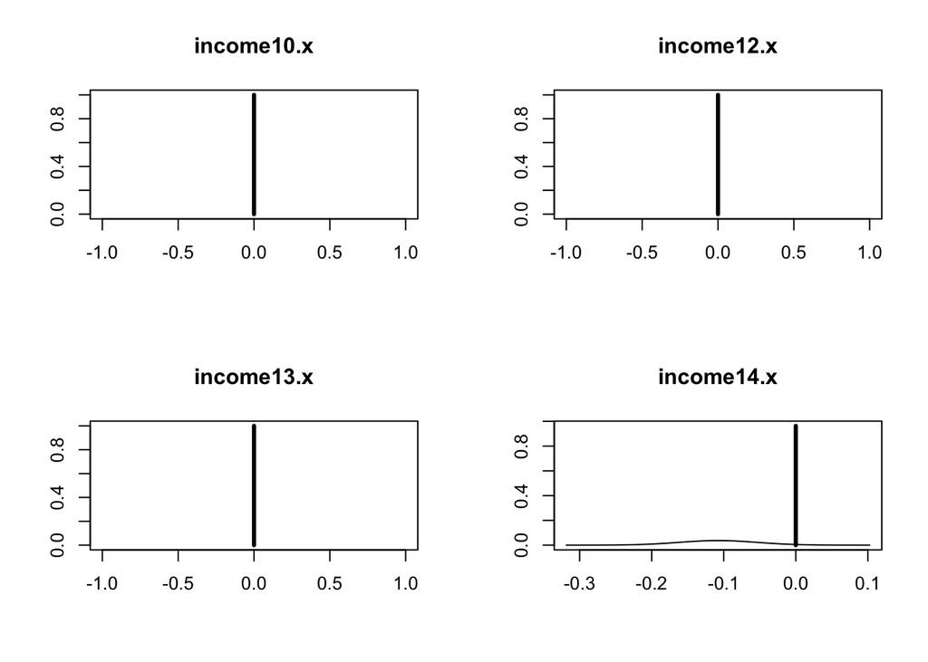

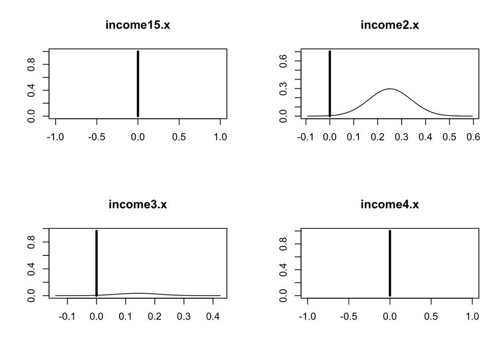

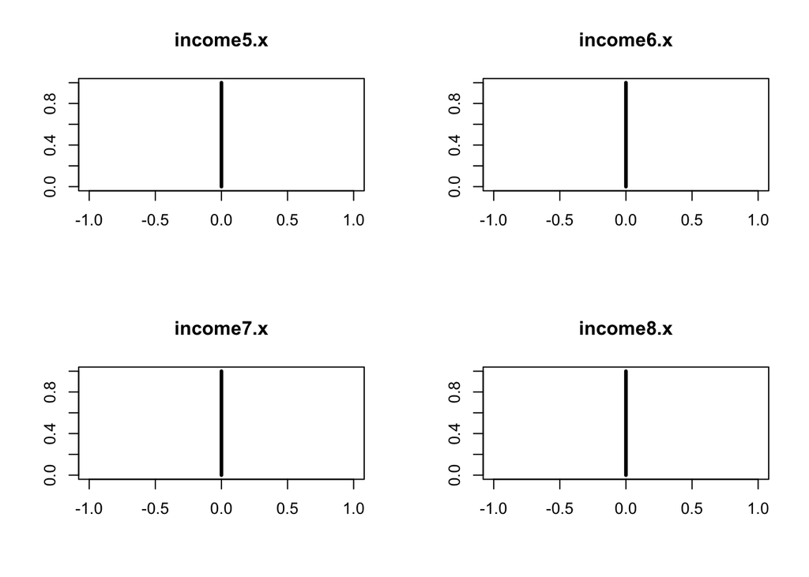

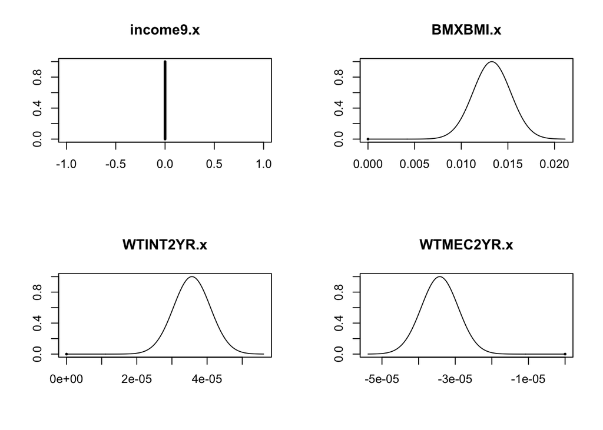

```r
plot (nhanes.bic.glm,mfrow=c(2,2))
```

```r
summary(nhanes.bic.glm, conditional=T, digits=3)
```

```
##
## Call:
## bic.glm.formula(f = Gender_binary ~ income + BMXBMI + WTINT2YR +     WTMEC2YR, data = nhanes_na_removed, glm.family = "binomial")
##
##
##   4  models were selected
##  Best  4  models (cumulative posterior probability =  1 ):
##
##             p!=0    EV        SD        cond EV    cond SD   model 1
## Intercept   100    -2.98e-01  5.56e-02  -2.98e-01  5.56e-02  -2.95e-01
## income10.x    0.0   0.00e+00  0.00e+00   0.00e+00  0.00e+00      .
## income12.x    0.0   0.00e+00  0.00e+00   0.00e+00  0.00e+00      .
## income13.x    0.0   0.00e+00  0.00e+00   0.00e+00  0.00e+00      .
## income14.x    3.7  -4.01e-03  2.29e-02  -1.08e-01  5.41e-02      .
## income15.x    0.0   0.00e+00  0.00e+00   0.00e+00  0.00e+00      .
## income2.x    29.7   7.45e-02  1.24e-01   2.51e-01  8.85e-02      .
## income3.x     3.5   4.91e-03  2.93e-02   1.42e-01  7.27e-02      .
## income4.x     0.0   0.00e+00  0.00e+00   0.00e+00  0.00e+00      .
## income5.x     0.0   0.00e+00  0.00e+00   0.00e+00  0.00e+00      .
## income6.x     0.0   0.00e+00  0.00e+00   0.00e+00  0.00e+00      .
## income7.x     0.0   0.00e+00  0.00e+00   0.00e+00  0.00e+00      .
## income8.x     0.0   0.00e+00  0.00e+00   0.00e+00  0.00e+00      .
## income9.x     0.0   0.00e+00  0.00e+00   0.00e+00  0.00e+00      .
## BMXBMI.x    100.0   1.33e-02  2.02e-03   1.33e-02  2.02e-03   1.33e-02
## WTINT2YR.x  100.0   3.57e-05  5.24e-06   3.57e-05  5.24e-06   3.57e-05
## WTMEC2YR.x  100.0  -3.42e-05  5.04e-06  -3.42e-05  5.04e-06  -3.42e-05
##
## nVar                                                            3
## BIC                                                          -1.28e+05
## post prob                                                     0.632
##             model 2    model 3    model 4
## Intercept   -3.04e-01  -2.85e-01  -3.02e-01
## income10.x      .          .          .
## income12.x      .          .          .
## income13.x      .          .          .
## income14.x      .      -1.08e-01      .
## income15.x      .          .          .
## income2.x    2.51e-01      .          .
## income3.x       .          .       1.42e-01
## income4.x       .          .          .
## income5.x       .          .          .
## income6.x       .          .          .
## income7.x       .          .          .
## income8.x       .          .          .
## income9.x       .          .          .
## BMXBMI.x     1.32e-02   1.32e-02   1.32e-02
## WTINT2YR.x   3.57e-05   3.58e-05   3.59e-05
## WTMEC2YR.x  -3.42e-05  -3.43e-05  -3.44e-05
##
## nVar           4          4          4
## BIC         -1.28e+05  -1.28e+05  -1.28e+05
## post prob    0.297      0.037      0.035
##
##   1  observations deleted due to missingness.
```

```r
nhanes_na_removed$WTINT2YR<-log(nhanes_na_removed$WTINT2YR)
nhanes_na_removed$WTMEC2YR<-log(nhanes_na_removed$WTMEC2YR)
nhanes_na_removed$BMXBMI<-log(nhanes_na_removed$BMXBMI)
nhanes_na_removed$WTINT2YR<-log(nhanes_na_removed$RIDAGEYR)
# nhanes.bic.surv <- bic.surv(BMXBMI,RIDAGEYR,data=nhanes_na_removed)
```

## Related Topics

| **Topics** | **Concepts** |
| --- | --- |
| ANOVA | Null hypothesis |
| Quantile factoring | use qualitative as levels |
| Cross-validation | k-fold, LOOCV |
| Model section | AIC, BIC, Cp |